# Fitting linear and non-linear equations by group

```r
library(forestmangr)
library(dplyr)
library(tidyr)

data(exfm14)
data_ex <- exfm14 %>% filter(strata%in%1:10)
data_ex
```

```
#> # A tibble: 485 × 4
#>   strata  plot   age    dh
#>    <dbl> <dbl> <dbl> <dbl>
#> 1      1     2    30  12.3
#> 2      1     2    42  16.3
#> 3      1     2    54  17.6
#> 4      1     2    66  18.9
#> 5      1     2    78  21.0
#> 6      1     2    90  20.5
#> # ℹ 479 more rows
```

In order to fit Schumacher’s dominant height model, we can use `lm_table`. Thanks to the `log` and `inv` functions, there is no need to create new variables:

```r
mod1 <- lm_table(data_ex, log(dh) ~ inv(age))
mod1
```

```
#>         b0        b1      Rsqr  Rsqr_adj Std.Error
#> 1 3.484289 -24.84688 0.5774814 0.5766066 0.1489379
```

To fit a non-linear model, like Chapman-Richards’ we can use the `nls_table` function. This function uses Levenberg-Marquardt’s algorithm by default, in order to assure a good fit. Since this is a non-linear fit, we have to input initial values for all coefficients:

```r
mod2 <- nls_table(data_ex, dh ~ b0 * (1 - exp( -b1 * age )  )^b2,
          mod_start = c( b0=23, b1=0.03, b2 = 1.3  ) )
mod2
```

```
#>         b0         b1       b2
#> 1 25.07289 0.04864685 2.210243
```

If we wanted to fit one model of each stratum, we can use the `.groups` argument:

```r
mod1 <- lm_table(data_ex, log(dh) ~ inv(age), .groups = "strata")
mod1
```

```
#>    strata       b0        b1      Rsqr  Rsqr_adj Std.Error
#> 1       1 3.409597 -23.89531 0.6735579 0.6626765 0.1231461
#> 2       2 3.438958 -20.93546 0.5838795 0.5748334 0.1161602
#> 3       3 3.466038 -24.71091 0.5240282 0.5145088 0.1672240
#> 4       4 3.503344 -23.68113 0.6594713 0.6511657 0.1146404
#> 5       5 3.536465 -26.23788 0.5750804 0.5692596 0.1571615
#> 6       6 3.541486 -26.18396 0.5843789 0.5758968 0.1589094
#> 7       7 3.546067 -28.33781 0.7170698 0.7125789 0.1331317
#> 8       8 3.385322 -22.29504 0.5114795 0.4966758 0.1641533
#> 9       9 3.444338 -23.34891 0.5151849 0.5062068 0.1638949
#> 10     10 3.411819 -24.00458 0.5749233 0.5585742 0.1491196
```

```r
mod2 <- nls_table(data_ex, dh ~ b0 * (1 - exp( -b1 * age )  )^b2,
          mod_start = c( b0=23, b1=0.03, b2 = 1.3  ),
          .groups = "strata" )
mod2
```

```
#>    strata       b0         b1        b2
#> 1       1 22.38251 0.06883817 3.9495071
#> 2       2 23.61424 0.08097176 5.4171092
#> 3       3 24.09040 0.05813164 2.9428225
#> 4       4 29.73188 0.02172249 0.8875606
#> 5       5 26.74705 0.04163860 1.8799458
#> 6       6 25.63739 0.05955898 3.4005108
#> 7       7 26.68246 0.03878189 1.8419905
#> 8       8 23.35938 0.05159001 2.2394412
#> 9       9 27.31603 0.02544091 0.9842925
#> 10     10 22.95016 0.06214439 3.3861913
```

If the fit is not ideal, it’s possible to use a dataframe with starting values for each stratum, and use it as an input for `mod_start`:

```r
tab_start <- data.frame(strata = c(1:10),
              rbind(
              data.frame(b0=rep(23, 5),b1=rep(0.03,5),b2=rep(1.3,5) ),
              data.frame(b0=rep(23, 5),b1=rep(0.03,5),b2=rep(.5,5) )))
tab_start
```

```
#>    strata b0   b1  b2
#> 1       1 23 0.03 1.3
#> 2       2 23 0.03 1.3
#> 3       3 23 0.03 1.3
#> 4       4 23 0.03 1.3
#> 5       5 23 0.03 1.3
#> 6       6 23 0.03 0.5
#> 7       7 23 0.03 0.5
#> 8       8 23 0.03 0.5
#> 9       9 23 0.03 0.5
#> 10     10 23 0.03 0.5
```

```r
mod2 <- nls_table(data_ex, dh ~ b0 * (1 - exp( -b1 * age )  )^b2,
          mod_start = tab_start,
          .groups = "strata" )
mod2
```

```
#>    strata       b0         b1        b2
#> 1       1 22.38251 0.06883817 3.9495071
#> 2       2 23.61424 0.08097176 5.4171092
#> 3       3 24.09040 0.05813164 2.9428225
#> 4       4 29.73188 0.02172249 0.8875606
#> 5       5 26.74705 0.04163860 1.8799458
#> 6       6 25.63740 0.05955884 3.4004949
#> 7       7 26.68250 0.03878163 1.8419741
#> 8       8 23.35905 0.05159620 2.2398949
#> 9       9 27.31667 0.02543790 0.9841984
#> 10     10 22.95016 0.06214456 3.3862119
```

Now we’re going to fit some other models. These are:

Schumacher:
$$Ln(DH) = \beta_0 + \beta_1
* \frac{1}{age}$$

Chapman-Richards:
$$DH = \beta_0 * (1 -
exp^{-\beta_1 * age})^{\beta_2}$$

Bayley-Clutter:
$$Ln(DH) = \beta_0 +
\beta_1 * \begin{pmatrix} \frac{1}{age} \end{pmatrix}
^{\beta_2}$$

Curtis:
$$DH = \beta_0 + \beta_1 *
\frac{1}{age}$$

We’ll fit these models and add their estimated values to the original data using the `merge_est` output and naming each estimated variable with the `est_name` argument:

```r
data_ex_est <- data_ex %>%
  lm_table(log(dh) ~ inv(age), .groups = "strata",
           output = "merge_est", est.name = "Schumacher") %>%

  nls_table(dh ~ b0 * (1 - exp( -b1 * age )  )^b2,
          mod_start = c( b0=23, b1=0.03, b2 = 1.3  ),.groups="strata",
          output ="merge_est",est.name="Chapman-Richards") %>%

  nls_table(log(dh) ~ b0 + b1 * ( inv(age)^b2 ) ,
          mod_start = c( b0=3, b1=-130, b2 = 1.5),.groups = "strata",
          output ="merge_est",est.name = "Bailey-Clutter") %>%

  lm_table(dh ~ inv(age), .groups = "strata",
           output = "merge_est", est.name = "Curtis")

head(data_ex_est)
```

```
#>   strata plot age       dh Schumacher Chapman-Richards Bailey-Clutter   Curtis
#> 1      1    2  30 12.29841   13.64110         13.10199       12.58661 13.61765
#> 2      1    2  42 16.32000   17.12709         17.86289       18.23334 17.58237
#> 3      1    2  54 17.58000   19.43531         20.31013       20.32246 19.78499
#> 4      1    2  66 18.94000   21.06362         21.45677       21.20276 21.18665
#> 5      1    2  78 21.04000   22.27015         21.97365       21.62661 22.15704
#> 6      1    2  90 20.48000   23.19865         22.20283       21.85316 22.86866
```

Ps: The `lm_table` function checks if the model has log in the y variable, and if it does, it removes it automatically when estimating variables. Because of that, there’s no need to calculate the exponential for the estimated variables.

In order to compare these models, we’ll calculate the root mean square error and bias for all models. To do this, we’ll gather all estimated variables in a single column using `tidyr::gather`, group by model, and use the `rmse_per` and `bias_per` functions:

```r
data_ex_est %>%
  gather(Model, Value,
         Schumacher, `Chapman-Richards`, `Bailey-Clutter`, Curtis) %>%
  group_by(Model) %>%
  summarise(
    RMSE = rmse_per(y = dh, yhat = Value),
    BIAS = bias_per(y = dh, yhat = Value) )
```

```
#> # A tibble: 4 × 3
#>   Model             RMSE      BIAS
#>   <chr>            <dbl>     <dbl>
#> 1 Bailey-Clutter    14.8  1.03e+ 0
#> 2 Chapman-Richards  14.7 -7.37e- 4
#> 3 Curtis            14.8 -3.70e-16
#> 4 Schumacher        15.0  1.03e+ 0
```

Another way of comparing and evaluating these models is using residual graphical analysis. The function `resid_plot` can help us with that:

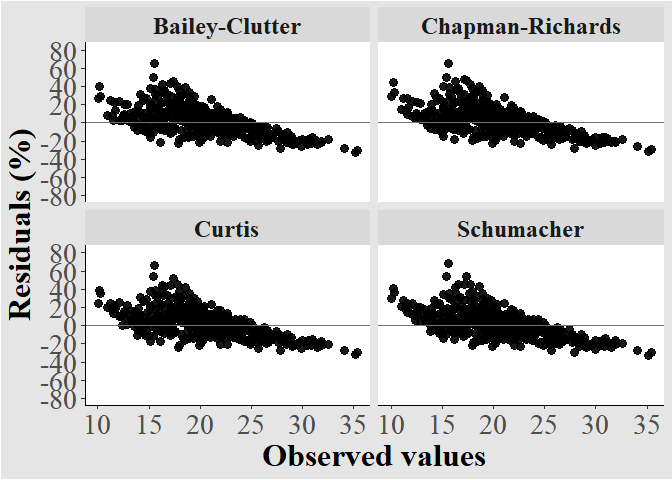

```r
resid_plot(data_ex_est, "dh", "Schumacher", "Chapman-Richards", "Bailey-Clutter", "Curtis")
```

There are other types of plots avaiable, such as histogram:

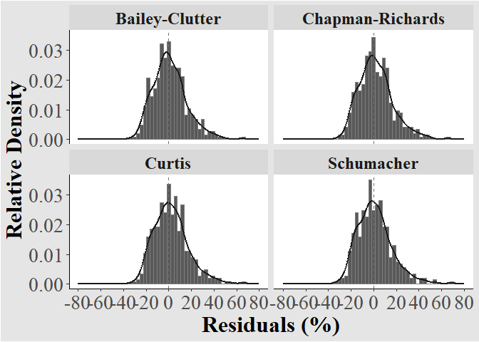

```r
resid_plot(data_ex_est, "dh", "Schumacher","Chapman-Richards","Bailey-Clutter", "Curtis",
           type = "histogram_curve")
```

And versus:

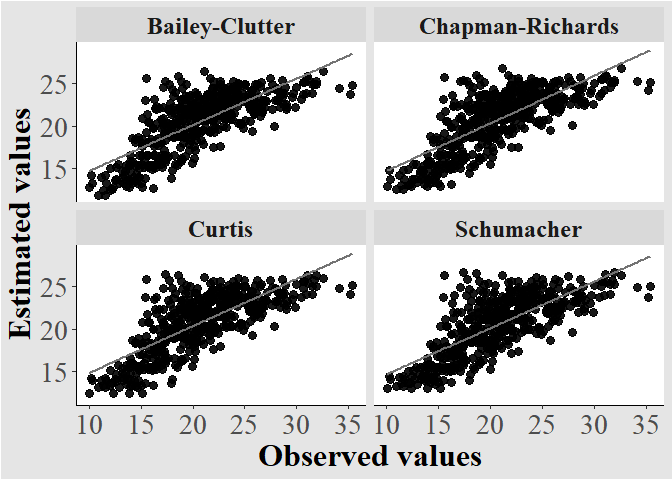

```r
resid_plot(data_ex_est, "dh", "Schumacher", "Chapman-Richards", "Bailey-Clutter", "Curtis",
           type = "versus")
```